```python
# Подгрузим необходимые для работы библиотеки
import glob
import numpy as np
import pandas as pd
import scipy
from scipy import signal, fftpack
import matplotlib.pyplot as plt
from sklearn.datasets import fetch_mldata
from sklearn.decomposition import PCA
from sklearn.manifold import TSNE
from mpl_toolkits.mplot3d import Axes3D
import seaborn as sns
%matplotlib inline
with pd.option_context("display.max_rows", 10, "display.max_columns", 20):
    print(pd.get_option("display.max_rows"))
    print(pd.get_option("display.max_columns"))
FN = 1
```

```
10
20
```

# Загрузка данных

Загрузим данные используя pandas, результаты контроля очищены от технической информации путем реализации класса и разбиения данных на результаты контроля и дополнительную техническую информацию.

Реализуем класс для хранения информации о экспериментах проведенных системой ПУЗК

# Определение расстояния между схемами прозвучивания

Взаимно корреляционные функции и расстояние между схемами прозвучивания, а также реализация метода класса, по нахождению кроосс-корреляционной функции, и приведению наборов данных к общей системе координат

```python
class SOP:
    control_results = None
    def __init__(self, filepath="SOP1.txt"):
        self.filepath = filepath

    def read_control_results(self):
        # В рамках текущего модуля пока избавимся от первого столбца с номерами измерений, пока в них нет необходимости
        splited_info = ""
        with open(self.filepath, mode="r", encoding="cp1251") as f:
            splited_info = f.readline()
        self.control_results=pd.read_csv(self.filepath, encoding="cp1251", delimiter = " ", header = None, skiprows = 1)
        self.control_results = self.control_results.drop(columns=[0])
        splited_info = splited_info.split(' ')
        self.date = splited_info[1]
        self.time = splited_info[2]
        self.temperature = splited_info[3]
        self.name = splited_info[16]

    def fix_shift_issue_cross_corr(self):
        # Нахождение сдвига используя кросс корреляцию
        for cont_res in self.control_results:
            f1 = self.control_results[1]
            f2 = self.control_results[cont_res]
            c = np.correlate(f1-np.mean(f1), f2-np.mean(f1), 'full')
            print(str(cont_res) + " ---> 1 Сдвиг в сторону системы координат равен"  , (np.argmax(c) - 1037))
            self.control_results[cont_res] = np.roll(self.control_results[cont_res],np.abs((np.argmax(c) - 1037)))
        shift_to_start_coordinate()

    def fix_shift_issue_fft(self):
        for cont_res in self.control_results:
            f1 = self.control_results[1]
            f2 = self.control_results[cont_res]
            A = fftpack.fft(f1)
            B = fftpack.fft(f2)
            Ar = -A.conjugate()
            Br = -B.conjugate()
#             print(str(cont_res) + " ---> 1 Сдвиг в сторону системы координат равен" , np.argmax(np.abs(fftpack.ifft(Ar*B))))
            print(str(cont_res) + " ---> 1 Сдвиг в сторону системы координат равен" ,np.argmax(np.abs(fftpack.ifft(A*Br))))
            self.control_results[cont_res] = np.roll(self.control_results[cont_res],np.abs(np.argmax(np.abs(fftpack.ifft(A*Br)))))
        shift_to_start_coordinate()

    def shift_to_start_coordinate(self):
        # Для всех последовательностей применим сдвиг до начала координат
        for cont_res in self.control_results:
            self.control_results[cont_res] = np.roll(self.control_results[cont_res],50)
```

```python
sop_list = []
sop_files = glob.glob("*.txt")
for file_path in sop_files:
    sop_list.append(SOP(file_path))

for sop in sop_list:
    sop.read_control_results()
    sop.control_results.head()
```

Пример нахождения сдвига используя кросс корреляцию

```python
# Нахождение сдвига используя кросс корреляцию
for cont_res in sop_list[0].control_results[1:]:
    f1 = sop_list[0].control_results[1]
    f2 = sop_list[0].control_results[cont_res]
    c = np.correlate(f1-np.mean(f1), f2-np.mean(f1), 'full')
    print(str(cont_res) + " ---> 1 Сдвиг в сторону системы координат равен"  , (np.argmax(c) - 1037))
```

```
1 ---> 1 Сдвиг в сторону системы координат равен 0
2 ---> 1 Сдвиг в сторону системы координат равен 460
3 ---> 1 Сдвиг в сторону системы координат равен -382
4 ---> 1 Сдвиг в сторону системы координат равен 552
5 ---> 1 Сдвиг в сторону системы координат равен 261
6 ---> 1 Сдвиг в сторону системы координат равен 364
7 ---> 1 Сдвиг в сторону системы координат равен 310
8 ---> 1 Сдвиг в сторону системы координат равен 310
9 ---> 1 Сдвиг в сторону системы координат равен -383
10 ---> 1 Сдвиг в сторону системы координат равен 552
11 ---> 1 Сдвиг в сторону системы координат равен 0
12 ---> 1 Сдвиг в сторону системы координат равен 236
13 ---> 1 Сдвиг в сторону системы координат равен 53
14 ---> 1 Сдвиг в сторону системы координат равен 282
15 ---> 1 Сдвиг в сторону системы координат равен 310
16 ---> 1 Сдвиг в сторону системы координат равен 310
```

Пример нахождения сдвига используя быстрое преобразование Фурье

```python
# Нахождение сдвига используя быстрое преобразование Фурье
for cont_res in sop_list[0].control_results[1:]:
    f1 = sop_list[0].control_results[1]
    f2 = sop_list[0].control_results[cont_res]
    A = fftpack.fft(f1)
    B = fftpack.fft(f2)
    Ar = -A.conjugate()
    Br = -B.conjugate()
#     print(cont_res, np.argmax(np.abs(fftpack.ifft(Ar*B))))
    print(str(cont_res) + " ---> 1 Сдвиг в сторону системы координат равен" ,np.argmax(np.abs(fftpack.ifft(A*Br))))
```

```
1 ---> 1 Сдвиг в сторону системы координат равен 0
2 ---> 1 Сдвиг в сторону системы координат равен 460
3 ---> 1 Сдвиг в сторону системы координат равен 656
4 ---> 1 Сдвиг в сторону системы координат равен 552
5 ---> 1 Сдвиг в сторону системы координат равен 261
6 ---> 1 Сдвиг в сторону системы координат равен 364
7 ---> 1 Сдвиг в сторону системы координат равен 310
8 ---> 1 Сдвиг в сторону системы координат равен 310
9 ---> 1 Сдвиг в сторону системы координат равен 658
10 ---> 1 Сдвиг в сторону системы координат равен 211
11 ---> 1 Сдвиг в сторону системы координат равен 0
12 ---> 1 Сдвиг в сторону системы координат равен 114
13 ---> 1 Сдвиг в сторону системы координат равен 53
14 ---> 1 Сдвиг в сторону системы координат равен 862
15 ---> 1 Сдвиг в сторону системы координат равен 308
16 ---> 1 Сдвиг в сторону системы координат равен 310
```

# Обоснование

Причиной высоких значений сдвига и функций кросс-корреляции является физическая удаленность и данные значения выглядят вполне реально, так как вся установка на указанной нами трубе занимает чуть больше одной трети всей окружности трубы, и удаленность значений найденная с помощью преобразования фурье и функции кросс кореляции выглядит вполне реально, однако значения после кросс кореляции на мой взгляд всё же более точны. Далее я буду использовать их для определения схем прозвучивания

# ОПРЕДЕЛЕНИЕ СХЕМ ПРОЗВУЧИВАНИЯ

В наших данных принимать значения могут только У() Соответственно Определим пары значений на одинаковом удалении 1 и 11 принимают сигнал в одном месте это У5 и У6 7 8 15 16 находятся в одном месте это 4 раздельно совмещённые эхо схемы обнаруживающие продольные несмежности 9 и 3 принимают сигнал в одном месте  
Так и должно быть, не успел (

```python
def display_values(dataframe):
    assert isinstance(dataframe, pd.DataFrame)
    for column in dataframe.columns:
        plt.figure(figsize=(15,3))
        plt.title(column)
        plt.plot(dataframe[column])
        plt.show()

def display_distribution(dataframe):
    assert isinstance(dataframe, pd.DataFrame)
    for column in dataframe.columns:
        plt.figure(figsize=(8,8))
        plt.title(column)
        dataframe[column].plot(kind="density")
        plt.show()
```

Посмотрим как изменились графики значений, распределений и боксплота после преобразований

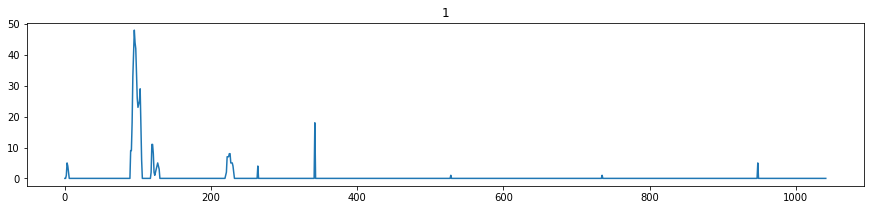

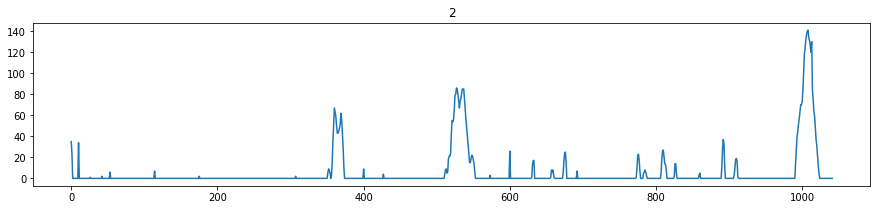

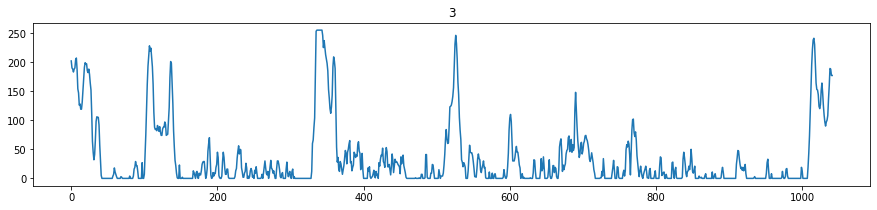

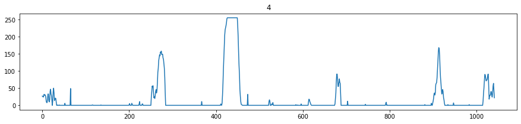

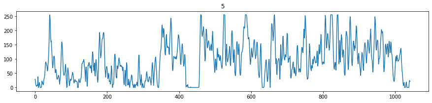

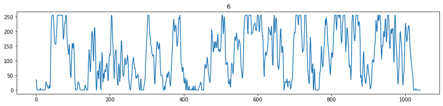

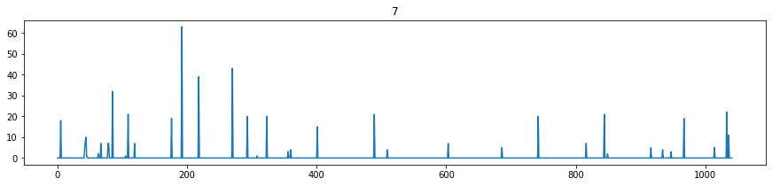

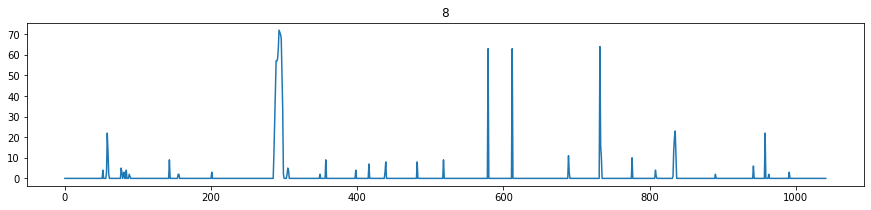

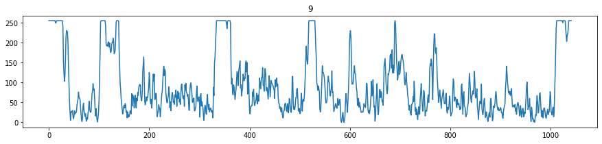

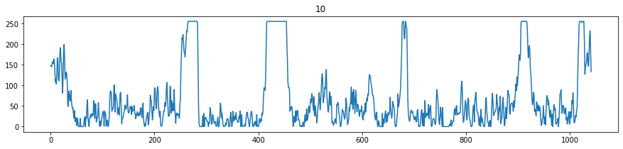

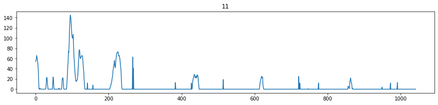

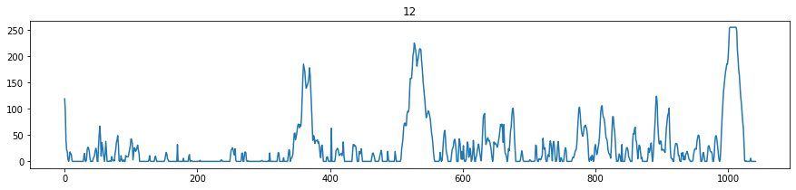

[21 more figures not shown]

```python
display_values(sop_list[FN].control_results)
display_distribution(sop_list[FN].control_results)
boxplot = sop_list[FN].control_results.boxplot(figsize=(17,17))
```

Графики без изменений

Построим матрицу корреляции для исходного набора данных

```python
corr = sop_list[0].control_results.corr()
corr.style.background_gradient(cmap='coolwarm').set_precision(2)
```

[output not shown]

Используя матрицу корреляции мы можем исключить незначащие данные по коэффициенту корреляции, и тем самым облегчить возможность корректной настройки модели классификации  
Можно отбросить признаки за номерами: 11, 4, 3, 16, 7

# Определение методов контроля и схем прозвучивания

В информационном документе представлены 3 метода ультразвукового прозвучивания:  
1) Эхо-метод - реализуется по принципу отражения от дефекта - Сигнала нет, если нет дефекта  
2) Теневой метод - просвечивания насквозь области с дефектом - Сигнал есть, если нет дефекта  
3) Эхо-контактный метод - Усиленный эжхо метод, по своему принципу и стат показателям располагается между Эхо методом и Теневым методом  
Ориентируясь на графики распределения, графики (боксплот ), и графики значений, можно эмпирическим путем найти соответствие методов УЗ контроля и  
Эхо-Метод: 1,2,7,8,11,4  
Теневой метод: 5, 6, 9, 10  
Эхо-контактный метод: 3, 13, 12, 14, 15 ,16

Разделение происходило следующим образом: Сначала были найдены крайние по боксплоту(медиана и квартили), и визуально похожие на эхо метод. сигналы относящиеся к Эхо методу - 6штук  
После были найдены сигналы относящиеся к теневому методу, также крайние по боксплоту(медиана и квартили), и визуально похожие на теневой метод - 4 штуки  
оставшиеся сигналы являлись Эхо контактными методами.

Мне было интересно взглянуть на визуализацию исходного признакового пространства  
после преобразования методом главных компонент,  
я получил следующее представление

# Посмотрим что изменилось в методе главных компонент

```python
pca = PCA(n_components=3)
pca_result = pca.fit_transform(sop_list[0].control_results.values)

sop_list[0].control_results['pca-one'] = pca_result[:,0]
sop_list[0].control_results['pca-two'] = pca_result[:,1]
sop_list[0].control_results['pca-three'] = pca_result[:,2]

print('Объясненная вариация по основному компоненту: {}'.format(pca.explained_variance_ratio_))
```

```
Объясненная вариация по основному компоненту: [0.33837924 0.17704233 0.17179405]
```

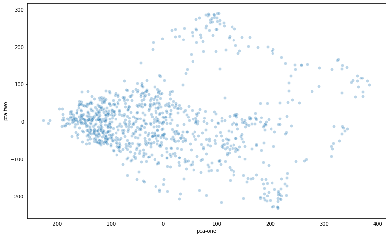

```python
plt.figure(figsize=(13,8))
sns.scatterplot(
    x="pca-one", y="pca-two",
    palette=sns.color_palette("hls", 10),
    data=sop_list[0].control_results,
    legend="full",
    alpha=0.3
)
```

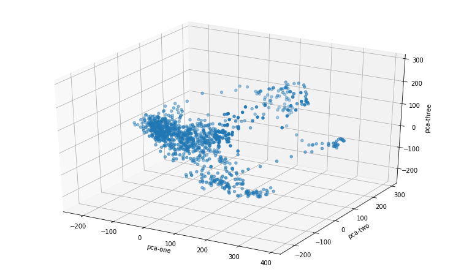

```python
ax = plt.figure(figsize=(13,8)).gca(projection='3d')
ax.scatter(
    xs=sop_list[0].control_results["pca-one"],
    ys=sop_list[0].control_results["pca-two"],
    zs=sop_list[0].control_results["pca-three"],
    cmap='tab10'
)
ax.set_xlabel('pca-one')
ax.set_ylabel('pca-two')
ax.set_zlabel('pca-three')
plt.show()
```

Пока такое представление нам мало о чём говорит, но всё же какие то выводы сделать возможно. Оба представления показывают что в наборе данных всё же есть какое то разделение на кластеры, видно плотный сгусток точек и отдаленный от него разряженную область точек. гипотетически что на 2х мерном, что на 3х мерном представлении может быть:  
1) Разделение на тип несплошности  
2) Разделение на наличие несплошности  
3) Разделение на сторону  
4) Разделение на метод УЗ  
Но это всего лишь гипотезы, и в данной задаче мы не ставим цели из исследовать.